# Day 1 · The letrozole cohort, and why a bag of codes fails

**Today's goal, in one sentence:** show a real example of two patients who look *completely identical* to a computer but are medically opposite cases — and use that to explain why the simplest way of describing a patient (a checklist of "does the patient have code X: yes/no") throws away exactly the information a good model would need.

**The problem.** Letrozole is prescribed for two unrelated reasons: as first-line ovulation induction for infertility, or as adjuvant aromatase-inhibitor therapy after breast cancer treatment. A bare drug-exposure code doesn't say which — the same molecule, the same claim shape, opposite clinical meaning.

*In plain terms: if all you know is "this patient was given letrozole," you cannot tell whether they're trying to get pregnant or recovering from cancer treatment. The drug code alone is silent on the reason it was prescribed.*

**The cohort**, from `sql/letrozole_cohort.sql`: every patient with a letrozole drug exposure (the RxNorm ingredient `letrozole` plus its standard descendant products — branded tablets, dose forms — resolved through `concept_ancestor`). This is the drug side of the ambiguity: anchoring on the exposure itself, rather than on a breast-cancer diagnosis, captures both indications by construction instead of biasing the sample toward oncology.

**The working hypothesis** (to test, not assume): anchoring on the drug rather than the cancer diagnosis should surface a much larger fertility-treatment population than a breast-cancer-anchored cohort would, since oncology-indication letrozole use is a small fraction of all letrozole prescriptions. `weak_labels()` and the NMF components below test this directly.

**Today's sub-goals:** get the OMOP extract for this cohort loaded as one event stream, understand the four preprocessing decisions baked into it, and see the exact failure that motivates the rest of the week.

### Summary

Every unsupervised method is a distance function plus a search procedure. Changing the representation moves the answer more than changing the algorithm does, so the leverage is upstream. Today is the upstream.

*In plain terms: "representation" just means how we turn a patient's messy history of visits, diagnoses, and prescriptions into rows and columns a computer can compare. Get that step wrong, and no amount of clever math afterward can fix it — the information is simply gone by the time the algorithm sees it. That's why today is entirely about that first step, before any modeling happens.*

### Three things that all get called "pattern"

*People use the word "pattern" loosely, for at least three different things. This table pins those down, so when someone says "we found a pattern," you know which of the three they mean and how much to trust it.*

| Term | What it is | Built on | Auditable? |
| --- | --- | --- | --- |
| **Cluster** | a group of similar patients | Day 2 | partly |
| **Motif** | a recurring *ordered* subsequence | Day 3 | yes |
| **Embedding** | a direction in a learned space | Day 4 | no |

Motifs are the current best deliverable for this project

### Technique chosen per subtopic

*For each question below, several statistical tools could answer it. This is the one this course uses, and why — the alternatives are listed too, in case a stakeholder asks "why not X."*

| Subtopic | We use | Mentioned only |
| --- | --- | --- |
| Similarity | **cosine** on binary codes | Jaccard, Dice, Gower, Mahalanobis |
| Linear reduction | **truncated SVD** | PCA (same thing, dense), ICA, factor analysis |
| Parts-based | **NMF** | archetypal analysis, sparse PCA |
| Non-linear view | **t-SNE** (ships with sklearn) | UMAP — better, `pip install umap-learn` |

## 0 · Getting the data

**Goal:** pull every letrozole-exposed patient's medical history out of the data warehouse and save it to disk as plain files, so the rest of the notebook runs offline and reproducibly, without hitting Snowflake every time.

`ethos_omop.extract_cohort()` pulls the letrozole-exposure cohort: any patient with a letrozole drug exposure, defined in `sql/letrozole_cohort.sql`. It dumps the same shape `extract_omop()` does — `master_*` as the source of truth, `ethos_dip` excluded on both `concept_id` and `source_concept_id` for every domain table, standard-named symlinks for `meds_etl_omop`, plus:

- **`concept.csv` slimmed** to the concept_ids the cohort actually references, instead of the full multi-million-row table.
- **`concept_ancestor` dumped too**, restricted to rows touching the cohort — needed for ontology rollup (drug products to ingredients, unspecified diagnoses to their parents).

*In plain terms: this is a one-time data export, like running a big report and saving the results as spreadsheets (CSV files) in a folder. Every cell below reads from that folder, not from Snowflake directly.*

```
import ethos_omop as eo
eo.extract_cohort("../../sql/letrozole_cohort.sql")   # -> ../../inputs/letrozole_cohort/
```

The next cell runs this once and skips it on every re-run once `../../inputs/letrozole_cohort/` exists.

**No Snowflake access, or want to see the notebook run against data whose right answer you already know?** Use the synthetic demo extract instead:

```
python make_demo_extract.py 2000
```

The demo extract has the **same schema** — integer `concept_id`s resolved through `concept.csv`, `master_*` table names, the symlinks — plus a `truth.csv` giving each patient's planted trajectory archetype. Real extracts have no `truth.csv`. That absence is the whole problem this course is about, and every notebook here works either way.

```python
# One-time export from Snowflake into local CSV files. Safe to re-run: it
# checks OUT_DIR first and skips the (slow) Snowflake pull if the files are
# already there, so you won't accidentally re-download everything every time
# you restart the notebook.
import os
import ethos_omop as eo

OUT_DIR     = "../../inputs/letrozole_cohort/"      # extract_cohort() output, relative to this notebook's dir
COHORT_SQL  = "../../sql/letrozole_cohort.sql"     # relative to this notebook's cwd

# Runs once: if OUT_DIR is already populated, notebooks load from disk and never
# re-hit Snowflake. Delete OUT_DIR (or pick a different one) to force a re-pull.
if not os.path.isdir(OUT_DIR):
    eo.extract_cohort(COHORT_SQL, out_dir=OUT_DIR)
else:
    print(f"{OUT_DIR}/ already populated -- skipping extract_cohort(). "
          f"Delete it to re-pull from Snowflake.")
```

```
../../inputs/letrozole_cohort// already populated -- skipping extract_cohort(). Delete it to re-pull from Snowflake.
```

```python
# Load everything from disk into memory as one big table of "events":
# one row per visit / diagnosis / procedure / drug / lab result, for every
# patient in the cohort. `codesets` translates raw medical codes into the
# readable clinical labels (letrozole, breast_cancer, mastectomy, ...) used
# throughout the rest of the notebook.
import numpy as np, pandas as pd, matplotlib.pyplot as plt
pd.set_option('display.width', 150); pd.set_option('display.max_columns', 40)

DOMAINS = ['Visit', 'Condition', 'Drug', 'Procedure', 'Measurement']

concept  = eo.load_concept(OUT_DIR)
codesets = eo.build_codesets(concept, verbose=False)
events   = eo.tag_events(eo.load_events(OUT_DIR, domains=DOMAINS), codesets)
person   = eo.load_person(OUT_DIR)
truth    = eo.load_truth(OUT_DIR)                   # None against real data

print(f"events {events.shape}   patients {events.person_id.nunique()}")
print(f"codeset coverage: {events.in_codeset.mean():.1%} of events carry a clinical tag")
print(f"truth labels: {'present (DEMO extract)' if truth is not None else 'ABSENT (real data)'}")
events.head(6)
```

```
events (2790127, 10)   patients 6103
codeset coverage: 6.2% of events carry a clinical tag
truth labels: ABSENT (real data)
```

|  | person_id | concept_id | event_date | domain | vocabulary_id | concept_code | concept_name | token | tag | in_codeset |
| --- | --- | --- | --- | --- | --- | --- | --- | --- | --- | --- |
| 0 | 1949 | 38004338 | 2019-07-01 | Visit | NUCC | 333600000X | Pharmacy | NUCC/333600000X | pharmacy | False |
| 1 | 1949 | 38004338 | 2019-07-01 | Visit | NUCC | 333600000X | Pharmacy | NUCC/333600000X | pharmacy | False |
| 2 | 1949 | 40223740 | 2019-07-01 | Drug | RxNorm | 999717 | potassium nitrate 0.05 MG/MG / sodium fluoride... | RxNorm/999717 | potassium_nitrate_0_05 | False |
| 3 | 1949 | 40223740 | 2019-07-01 | Drug | RxNorm | 999717 | potassium nitrate 0.05 MG/MG / sodium fluoride... | RxNorm/999717 | potassium_nitrate_0_05 | False |
| 4 | 1949 | 38004338 | 2019-09-25 | Visit | NUCC | 333600000X | Pharmacy | NUCC/333600000X | pharmacy | False |
| 5 | 1949 | 38004338 | 2019-09-25 | Visit | NUCC | 333600000X | Pharmacy | NUCC/333600000X | pharmacy | False |

```python
# Sanity check: how big is what we just loaded? Useful to know before you
# wait on a slow cell later, and a quick way to notice if an extract came
# back suspiciously empty or huge.
print(eo.describe_extract(OUT_DIR).to_string(index=False))
```

```
                           file    rows    MB
    master_visit_occurrence.csv 1023526 128.3
       master_drug_exposure.csv  617441 120.1
master_condition_occurrence.csv  527413  77.2
           concept_ancestor.csv  515615  11.3
master_procedure_occurrence.csv  441912  65.4
         master_measurement.csv  382516  51.9
         master_observation.csv  273404  33.7
                    concept.csv   12497   1.6
                     person.csv    6103   0.8
                      death.csv       0   0.0
```

## 1 · Four decisions already made for you

**Goal:** flag four judgment calls baked into the data-loading step above, before you trust any number that comes out of it. None of these are bugs — they're modelling choices someone had to make, and you should know what they are.

**1. Standard concepts only.** `load_events()` keeps `standard_concept == 'S'` and drops `concept_id = 0` (unmapped). Note the exclusion idiom in the extract is `IS DISTINCT FROM 'ethos_dip'`, not `<> 'ethos_dip'` — the latter silently drops NULLs.

*In plain terms: medical coding systems (ICD, SNOMED, etc.) have multiple ways to say the same thing. "Standard concepts" is OMOP's canonical, de-duplicated version of each code — we only keep those, so the same diagnosis isn't double-counted under two different code spellings.*

**2. `concept_code` stays a string.** Never let pandas parse it as numeric; leading zeros and alphanumeric codes both break.

*In plain terms: some medical codes look like numbers (e.g. `"0042"`) but aren't meant to be treated as one — turning them into an actual number silently drops the leading zero and corrupts the code.*

**3. Claims carry a DATE, not a timestamp.** Same-day events have no true order. `DOMAIN_ORDER` breaks ties deterministically — visit, then condition, procedure, measurement, drug, observation. It is arbitrary and it is written down. Stanford's CLMBR was built for minute-level resolution; we do not have that, and pretending otherwise is where silent errors come from.

*In plain terms: claims data tells you "something happened on March 3rd," not "at 2:14pm." If five things happened the same day, we can't know their real order — so we pick one consistent order and are upfront that it's a guess, rather than pretending we have more precision than we do.*

**4. There is no `observation_period` in the extract.** `observation_window()` derives a proxy from first and last observed event, which **understates** the true window. Anyone whose history starts near their first event is left-truncated: "no prior diagnosis" may mean "not observed yet."

*In plain terms: we only see what's in this data source. "This patient has no record of diabetes" might mean they truly don't have it, or it might just mean we started watching them too late to see it. Absence of a code is not proof of absence of the condition.*

```
count     6103.0
mean      2294.0
std       2201.0
min          0.0
25%       2140.0
50%       2421.0
75%       2515.0
max      99766.0
```

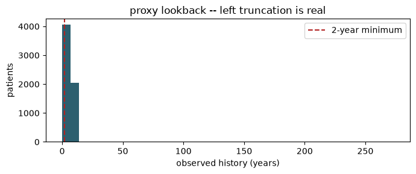

```
93 patients (1.5%) have under 2 years of history.
Exclude them from any analysis that depends on the ABSENCE of a code.
```

```python
# How much history do we actually have per patient? (See point 4 above --
# this is the proxy lookback window, not a true observation period.) The
# 2-year line is a common minimum bar for "long enough history to trust an
# absence of a code."
win = eo.observation_window(events)
print(win.lookback_days.describe().round(0).to_string())

plt.figure(figsize=(7, 3))
plt.hist(win.lookback_days / 365.25, bins=40, color='#2C5F6F')
plt.axvline(2, ls='--', c='firebrick', label='2-year minimum')
plt.xlabel('observed history (years)'); plt.ylabel('patients')
plt.title('proxy lookback -- left truncation is real'); plt.legend()
plt.tight_layout(); plt.show()

SHORT = win.loc[win.lookback_days < 730, 'person_id']
print(f"\n{len(SHORT)} patients ({len(SHORT)/len(win):.1%}) have under 2 years of history.")
print("Exclude them from any analysis that depends on the ABSENCE of a code.")
```

## 2 · Concept sets, resolved by name

**Goal:** show how a clinical concept like "letrozole" turns into an actual, checkable list of medical codes — and why we resolve it by *name* instead of hand-typing code numbers.

`CODESETS` in `ethos_omop.py` maps a clinical label to name patterns plus vocabularies. Resolving by name rather than hardcoding concept_ids means the same notebook runs against real Snowflake concepts and the demo extract alike.

*In plain terms: instead of writing down a fixed list of magic numbers ("code 19022830 means letrozole"), we write down a search pattern ("anything whose name matches 'letrozole' in the RxNorm vocabulary") and let the computer look up the matching codes every time. That way the same notebook keeps working even if the underlying code numbers differ between data sources.*

**Always eyeball the resolution before trusting it.** This is the step where a bad regex quietly poisons everything downstream.

```python
# Eyeball it: what did the "letrozole" pattern actually match? One row here
# means one specific product code -- exactly what you want to see before
# trusting anything downstream.
eo.resolve(concept, ['letrozole'], vocabularies=['RxNorm', 'RxNorm Extension'])
```

|  | concept_id | concept_name | vocabulary_id | concept_code | domain_id |
| --- | --- | --- | --- | --- | --- |
| 9756 | 19022830 | letrozole 2.5 MG Oral Tablet | RxNorm | 200064 | Drug |
| 11200 | 1315947 | letrozole 2.5 MG Oral Tablet [Femara] | RxNorm | 153124 | Drug |

```python
# Medical coding systems are hierarchical: a drug "ingredient" (letrozole)
# can have several branded/dosed "products" under it, and a diagnosis can
# have several more specific children. `concept_ancestor` lets us walk that
# hierarchy in either direction.

# On real data, roll a drug ingredient DOWN to all its products via concept_ancestor.
lz = codesets['letrozole']
print("letrozole concepts, direct:      ", len(lz))
print("letrozole concepts, + descendants:", len(eo.expand_descendants(lz)))

# And roll an unspecified diagnosis UP to its parents -- e.g. `breast_cancer`,
# the comorbidity marker that distinguishes this cohort's oncology-indication
# subgroup (letrozole is the anchor here, not breast_cancer -- see Table 1).
bc = codesets['breast_cancer']
print("breast cancer parents, 1 level up:  ", len(eo.roll_up(bc, levels=1)))
```

```
letrozole concepts, direct:       2
letrozole concepts, + descendants: 2
breast cancer parents, 1 level up:   1
```

```python
# `tag` collapses many concept_ids into one readable clinical label.
# Untagged events fall back to a slug of concept_name so sequences stay legible.
# What are the most common tags overall, and what fraction of all events
# actually got one of our curated labels versus falling back to a raw name?
print(events.tag.value_counts().head(15).to_string())
print(f"\ntagged into a codeset: {events.in_codeset.mean():.1%}")
```

```
tag
pharmacy                  603471
office_visit              190404
venipuncture_for_blood     45493
ovarian_reserve_test       37143
infectious_agent_detec     30927
somatic_dysfunction_of     30924
therapeutic_procedure_     29269
levothyroxine_sodium_0     26503
letrozole                  23631
telehealth                 21938
chiropractic_manipulat     21171
estradiol_total            18718
infertility                17745
psychotherapy_60_minut     17512
acupuncture_1_or_more_     16756

tagged into a codeset: 6.2%
```

*In plain terms: we only defined clinical labels (letrozole, mastectomy, breast_cancer, ...) for the codes relevant to this specific question. Everything else in a patient's record still exists in the data, we just haven't given it a friendly name -- it isn't lost, and it's part of what later, more automated methods (Day 4's embeddings) can pick up on that our hand-picked labels can't.*

## 3 · The bag of codes, and the exact failure

**Goal for this section:** build the simplest possible patient representation — a checklist of which codes each patient has — and then show exactly where it breaks.

```python
# The "bag of codes": one row per patient, one column per code, 1 if the
# patient ever had that code and 0 if not. This throws away *when* things
# happened and *how many times* -- it's the simplest representation there
# is, and the one we're about to show fails.
X = eo.bag_of_codes(events, min_count=20)
print(X.shape)
X.iloc[:5, :8]
```

```
(6103, 3513)
```

| tag person_id | 0_25_mg_0_5_mg_dose_1_ | 0_25_mg_0_5_mg_dose_3_ | 0_2_ml_sars_cov_2_covi | 0_3_ml_enoxaparin_sodi | 0_3_ml_sars_cov_2_covi | 0_4_ml_adalimumab_100_ | 0_4_ml_adalimumab_adaz | 0_4_ml_adalimumab_atto |
| --- | --- | --- | --- | --- | --- | --- | --- | --- |
| 1949 | 0 | 0 | 0 | 0 | 0 | 0 | 0 | 0 |
| 4358 | 0 | 0 | 0 | 0 | 0 | 0 | 0 | 0 |
| 4531 | 0 | 0 | 0 | 0 | 0 | 0 | 0 | 0 |
| 5216 | 0 | 0 | 0 | 0 | 0 | 0 | 0 | 0 |
| 5294 | 0 | 0 | 0 | 0 | 0 | 0 | 0 | 0 |

**Goal:** get a feel for `X` before we do anything clever with it — which codes are common, which are rare, and how that's different from what an NMF component (two sections down) will tell us.

Prevalence read directly off `X`, before any factorization -- contrasted with the NMF-loading readout two sections down. A loading tells you what's characteristic of a *component*, not how common a code is overall: `letrozole` is ~100% prevalent here yet won't dominate any single NMF component once it's dropped as near-constant.

*In plain terms: "prevalence" here just means "what % of patients have this code at all." That's a different question from "which codes define this cluster/component" -- a code can be common across the whole cohort (like `letrozole`, since that's how the cohort was defined) without being distinctive of any particular subgroup.*

```
3513 codes, prevalence range 0.016% - 100.000%
```

| tag | prevalence |
| --- | --- |
| letrozole | 100.0% |
| pharmacy | 100.0% |
| office_visit | 76.4% |
| venipuncture_for_blood | 62.4% |
| infectious_agent_detec | 56.5% |
| sars_cov_2_covid_19_va | 51.1% |
| complete_blood_count_w | 47.6% |
| thyroid_stimulating_ho | 47.4% |
| infectious_agent_antig | 46.9% |
| periodic_comprehensive | 46.0% |
| doxycycline_hyclate_10 | 44.8% |
| ovarian_reserve_test | 44.0% |
| urinalysis_by_dip_stic | 43.5% |
| comprehensive_metaboli | 42.3% |
| gynecologic_examinatio | 40.8% |
| hemoglobin_a1c_measure | 40.6% |
| pregnancy_test | 40.5% |
| amoxicillin_875_mg_cla | 39.6% |
| 6_azithromycin_250_mg_ | 38.7% |
| general_examination_of | 38.4% |

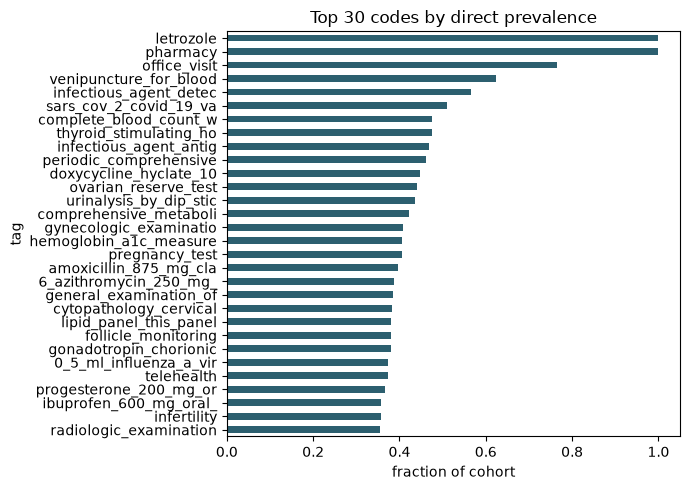

```python
# How common is each code across the whole cohort? (Just column-wise
# averages of the 0/1 matrix above -- no modelling yet.)
prevalence = X.mean().sort_values(ascending=False)
print(f"{len(prevalence)} codes, prevalence range "
      f"{prevalence.min():.3%} - {prevalence.max():.3%}")
display(prevalence.head(20).to_frame('prevalence').style.format('{:.1%}'))

plt.figure(figsize=(7, 5))
prevalence.head(30).iloc[::-1].plot.barh(color='#2C5F6F')
plt.xlabel('fraction of cohort'); plt.title('Top 30 codes by direct prevalence')
plt.tight_layout(); plt.show()
```

```python
# The punchline of the whole notebook: find one letrozole+breast_cancer
# patient labelled "fertility" and one labelled "oncology" by the rule-based
# check below, then show that the bag-of-codes view (X) can't tell them
# apart at all, even though their real timelines obviously can.
weak = eo.weak_labels(events)                      # rule-based probe labels
lab  = weak.set_index('person_id').weak_label

both = [p for p in X.index
        if X.loc[p].get('letrozole', 0) == 1
        and X.loc[p].get('breast_cancer', 0) == 1
        and p in lab.index]

a = next((p for p in both if lab[p] == 'fertility'), None)
b = next((p for p in both if lab[p] == 'oncology'),  None)
assert a and b, ("No identical-bag pair found in this sample. Increase the extract "
                 "size, or inspect `both` to see which side is missing.")

# Same view, plus a few randomly-picked columns where they DO differ -- shown
# side by side so it's clear these two patients aren't identical everywhere,
# just on the two columns that matter for the fertility-vs-oncology question.
diff_cols_all = X.columns[X.loc[a] != X.loc[b]]
diff_cols = list(pd.Index(diff_cols_all).to_series()
                  .sample(n=min(3, len(diff_cols_all)), random_state=0))
print("bag-of-codes view -- identical on letrozole/breast_cancer, "
      f"differs on {diff_cols}:")
display(X.loc[[a, b], ['letrozole', 'breast_cancer'] + diff_cols])

print("\nactual timelines -- obviously different:")
# FOCUS = eo.FERTILITY_TAGS / eo.ONCOLOGY_TAGS -- the same constants
# weak_labels() used to build `lab` -- plus the exposure/anchor tags, so this
# timeline shows the full evidence base behind the label instead of a
# hand-picked subset that can drift from it. Tags that never occurred for a
# given patient simply produce no row below, so this costs nothing visually.
FOCUS = ['letrozole', 'breast_cancer'] + eo.FERTILITY_TAGS + eo.ONCOLOGY_TAGS
for pid in (a, b):
    s = events[(events.person_id == pid) & events.tag.isin(FOCUS)]
    print(f"\n  person_id {pid}  ({lab[pid]})")
    print(s[['event_date', 'tag']].drop_duplicates('tag').to_string(index=False))
```

```
letrozole patients: 6103   labelled: 4309   both-evidence (dropped): 542   no-evidence (dropped): 1252
bag-of-codes view -- identical on letrozole/breast_cancer, differs on ['cytopathology_cervical', 'smn1_survival_of_motor', '24_hr_oxybutynin_chlor']:
```

| tag person_id | letrozole | breast_cancer | cytopathology_cervical | smn1_survival_of_motor | 24_hr_oxybutynin_chlor |
| --- | --- | --- | --- | --- | --- |
| 4460222 | 1 | 1 | 1 | 1 | 1 |
| 178752 | 1 | 1 | 0 | 0 | 0 |

```
actual timelines -- obviously different:

  person_id 4460222  (fertility)
event_date            tag
2021-04-22 pregnancy_test
2025-06-21      letrozole
2026-07-24  breast_cancer

  person_id 178752  (oncology)
event_date            tag
2020-02-12  breast_cancer
2024-09-11      letrozole
2025-05-23 receptor_assay
```

This is not a modelling failure. No estimator can recover something the input does not contain.

*In plain terms: this isn't a case of "use a fancier algorithm and it'll figure it out." The bag-of-codes table literally does not contain the information needed to tell these two patients apart -- both rows are 1, 1. No amount of machine learning can pull a distinction out of data where the distinction was never recorded in the first place. You have to fix the representation, not the model.*

### On `weak_labels()`

**Goal:** since there's no ground-truth "this patient took letrozole for fertility / for cancer" label in claims data, build a trustworthy *stand-in* label we can use to check our work — and be upfront about how it's built and where it can go wrong.

There are no adjudicated labels in claims data. `weak_labels()` builds probe labels for the letrozole indication from **corroborating co-evidence only** — clomiphene, gonadotropins and infertility diagnoses on one side; mastectomy, biopsy, tamoxifen and anastrozole on the other. Patients with both kinds of evidence, or neither, are dropped, and the counts are printed so you can see how many.

*In plain terms: instead of guessing the reason for letrozole directly, we look for other, more specific evidence nearby — did the patient also have a fertility drug or an infertility diagnosis? Did they also have a mastectomy or a cancer drug? If the evidence points clearly one way, we use that as the label. If it points both ways, or neither way, we honestly say "we don't know" and drop them rather than force a guess.*

**The time delta is deliberately not used.** If you label by "drug before diagnosis" and then test whether the time delta predicts the label, you get perfect accuracy by construction and have learned nothing. These labels are for evaluation, never features.

*In plain terms: it would be tempting to say "letrozole came before the cancer diagnosis, so it must be fertility-related." But that's using the very thing we're trying to test (timing) to build the answer key -- then "discovering" that timing predicts the answer would be circular, not a real finding. So the answer key is built from a different, independent kind of evidence, and timing is only used afterward to see if it can predict that answer.*

## 4 · Distance metrics disagree

**Goal:** show that "how similar are two patients" isn't one universal number — the metric you pick changes the answer, and picking the wrong one for claims data quietly breaks everything downstream.

```python
from sklearn.metrics import pairwise_distances

# letrozole is the cohort anchor here -- 100% prevalence (confirmed below), so
# it's a constant column that carries no discriminative signal and would just
# eat a component. Drop it before any distance/SVD/NMF fit; X itself (with
# the column) stays untouched for the two-patient demo above.
X_nmf = X.drop(columns=['letrozole'])
Xv  = X_nmf.values.astype(float)

# First: pick 400 random patients and measure how "far apart" every pair is,
# under two different definitions of distance. If cosine and jaccard disagree
# on how spread out the cohort is, that's a sign the metric matters, not just
# the data.
sub = Xv[:400]
for m in [#'euclidean',
          'cosine', 'jaccard']:
    D  = pairwise_distances(sub, metric=m)
    iu = np.triu_indices(len(sub), 1)
    print(f"{m:10s} mean={D[iu].mean():.3f}  sd={D[iu].std():.3f}")

# Second: for one specific patient (`a`, our fertility case from the demo
# above), who are their 5 nearest neighbours under each metric, and what
# weak label do those neighbours carry? Also report the direct a<->b
# distance, since b (the oncology case) is exactly the contrast we want.
posa = list(X.index).index(a)
posb = list(X.index).index(b)
print()
for m in [#'euclidean',
          'cosine', 'jaccard']:
    D  = pairwise_distances(Xv[posa:posa+1], Xv, metric=m)[0]
    nn = [X.index[i] for i in np.argsort(D)[1:6]]
    print(f"{m:10s} neighbours of {a}: {[lab.get(p, '?') for p in nn]}")
    print(f"{m:10s} distance({a}, {b}) = {D[posb]:.3f}")
```

```
cosine     mean=0.819  sd=0.077
jaccard    mean=0.908  sd=0.048
```

```
cosine     neighbours of 4460222: ['?', '?', '?', 'fertility', 'fertility']
cosine     distance(4460222, 178752) = 0.921
jaccard    neighbours of 4460222: ['?', '?', '?', 'fertility', 'fertility']
jaccard    distance(4460222, 178752) = 0.967
```

**Rule of thumb for claims: use cosine on binary or count code vectors.** Euclidean punishes patients simply for having long histories, so the distance ends up driven by utilisation volume rather than clinical content — which in your data is partly a function of what got ordered during underwriting.

*In plain terms: a patient with 200 recorded codes isn't automatically "less similar" to everyone else than a patient with 20 codes — but a naive distance metric (Euclidean) treats it that way, because it's sensitive to how many codes are turned on, not just which ones. Cosine distance cares about the pattern of codes, not the raw count, which is what we actually want to compare.*

## 5 · The curse of dimensionality

**Goal:** show why "just add more codes" eventually backfires — past a certain number of columns, distance stops being meaningful at all.

*In plain terms: with only a handful of columns, "similar" and "different" are easy to tell apart. Once you have tens of thousands of columns and each patient only has a handful of them turned on, almost every pair of patients ends up looking roughly equally (dis)similar to each other -- there's no longer a meaningful "close" versus "far." This is a general math fact (the "curse of dimensionality"), not something specific to our data.*

```python
# Not our data -- pure demonstration. Make random sparse 0/1 tables (2% of
# cells "on", like real code data) of increasing width, and watch the ratio
# of the closest pair's distance to the farthest pair's distance collapse
# toward 1 as width grows. That's the curse of dimensionality happening in
# front of you, independent of anything about breast cancer or letrozole.
rng = np.random.default_rng(0)
print(f"{'dims':>6} {'min/max distance ratio':>24}")
for d in [10, 50, 200, 1000, 5000]:
    Zr = (rng.random((200, d)) < 0.02).astype(float)     # sparse, like code data
    D  = pairwise_distances(Zr)
    iu = np.triu_indices(200, 1)
    print(f"{d:>6} {D[iu].min() / D[iu].max():>24.3f}")
print("\nRatio -> 1 means every patient is equally far from every other.")
```

```
  dims   min/max distance ratio
    10                    0.000
    50                    0.000
   200                    0.000
  1000                    0.568
  5000                    0.782

Ratio -> 1 means every patient is equally far from every other.
```

## 6 · Truncated SVD and NMF

**Goal:** compress thousands of sparse code columns down into a handful of numbers per patient that are actually usable for distance/clustering/visualization — and see two different ways of doing that compression.

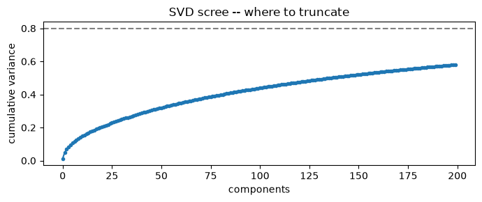

```python
from sklearn.decomposition import TruncatedSVD, NMF
from sklearn.preprocessing import normalize

# SVD finds the directions that explain the most variation in the data --
# similar in spirit to PCA. Its components can be positive or negative and
# don't have a clean "these codes belong to this theme" reading, but they're
# a solid general-purpose compression. Normalize first so this lines up with
# the cosine geometry we already decided was the right one for this data.
Xn  = normalize(Xv)                                  # cosine geometry, done properly
svd = TruncatedSVD(n_components=min(200, Xv.shape[1] - 1), random_state=0).fit(Xn)
Z   = svd.transform(Xn)

# How many components until we've captured most of the signal? The scree
# plot below answers that -- steep rise then flattening out means most of
# what matters is in the first handful of components.
plt.figure(figsize=(7, 3))
plt.plot(np.cumsum(svd.explained_variance_ratio_), marker='o', ms=3)
plt.axhline(0.8, ls='--', c='grey')
plt.xlabel('components'); plt.ylabel('cumulative variance')
plt.title('SVD scree -- where to truncate'); plt.tight_layout(); plt.show()
```

```python
# NMF factorises into non-negative PARTS, so each component reads as a set of
# co-occurring codes. Unlike SVD components you can name them.
#
# In plain terms: NMF is only allowed to add codes together, never subtract
# them, so each component ends up looking like "a bundle of codes that tend
# to show up together" -- e.g. "chemotherapy + antineoplastic drug" reads
# as an actual clinical bundle, not an abstract direction in space. That's
# why we print the top-5 codes per component below: it's how you check
# whether a component actually means something clinically, or is noise.
#
# We fit twice, at k=5 and k=12, to see how the story changes with more
# components allowed (see the annotated discussion two cells down). Each
# component is also sized -- by dominant-component count and % of the
# cohort -- and each top code is shown with its % share of that component's
# total loading, so you can see at a glance both which bundles are large
# populations and which codes actually drive each one.
# for k in [3, 5, 8, 12]:
for k in [5,12]:
    nmf = NMF(n_components=k, init='nndsvd', random_state=0, max_iter=800).fit(Xv)
    H   = pd.DataFrame(nmf.components_, columns=X_nmf.columns)
    dom = pd.Series(nmf.transform(Xv).argmax(axis=1)).value_counts().sort_index()
    print (f"\nNMF with {k} components:")
    for c in range(k):
        n    = int(dom.get(c, 0))
        row  = H.iloc[c]
        top  = row.sort_values(ascending=False).head(10)
        share = (top / row.sum() * 100).round(1)
        codes = [f"{name} ({pct}%)" for name, pct in share.items()]
        print(f"component {c} (n={n}, {n / len(X_nmf) * 100:.1f}%): {codes}")
```

```
NMF with 5 components:
component 0 (n=1052, 17.2%): ['lipid_panel_this_panel (0.7%)', 'comprehensive_metaboli (0.7%)', 'radiologic_examination (0.7%)', 'complete_blood_count_w (0.6%)', 'hemoglobin_a1c_measure (0.6%)', 'general_examination_of (0.6%)', 'periodic_comprehensive (0.6%)', 'venipuncture_for_blood (0.6%)', 'urina…
component 1 (n=2715, 44.5%): ['pharmacy (2.2%)', 'office_visit (1.5%)', 'amoxicillin_875_mg_cla (1.2%)', 'sars_cov_2_covid_19_va (1.2%)', '6_azithromycin_250_mg_ (1.2%)', 'doxycycline_hyclate_10 (1.2%)', 'ibuprofen_800_mg_oral_ (1.1%)', 'prednisone_20_mg_oral_ (1.0%)', '0_5_ml_influenza_a_vir (1.0%)…
component 2 (n=916, 15.0%): ['art_procedure (1.8%)', 'gonadotropin_drug (1.6%)', 'estradiol_total (1.6%)', 'infertility (1.5%)', 'ovarian_reserve_test (1.5%)', 'estradiol_2_mg_oral_ta (1.4%)', 'gonadotropin_chorionic (1.3%)', 'gnrh_agonist (1.3%)', 'follicle_monitoring (1.2%)', 'saline_infusion_sono…
component 3 (n=1102, 18.1%): ['pregnancy_outcome (1.5%)', 'ultrasound_pregnant_ut (1.5%)', 'glucose_measurement_po (1.2%)', 'routine_obstetric_care (1.2%)', 'postnatal_maternal_exa (1.1%)', 'bacterial_culture_urin (1.1%)', 'transvaginal_obstetric (1.1%)', 'rbc_antibody_detection (1.0%)', 'abo_typing…
component 4 (n=318, 5.2%): ['cftr_cystic_fibrosis_t (2.9%)', 'hexa_hexosaminidase_a_ (2.8%)', 'smn1_survival_of_motor (2.8%)', 'ikbkap_inhibitor_of_ka (2.8%)', 'fmr1_fragile_x_messeng (2.7%)', 'aspa_aspartoacylase_eg (2.7%)', 'gba_glucosidase_beta_a (2.7%)', 'fancc_fanconi_anemia_c (2.6%)', 'molecul…

NMF with 12 components:
component 0 (n=375, 6.1%): ['art_procedure (4.1%)', 'infertility (3.4%)', 'estradiol_total (3.2%)', 'ovarian_reserve_test (3.1%)', 'follicle_monitoring (3.0%)', 'ultrasound_pelvic_nono (2.9%)', 'gonadotropin_chorionic (2.8%)', 'ocular_prosthetic_serv (2.6%)', 'saline_infusion_sonohy (2.5%)', 'reprod…
component 1 (n=1594, 26.1%): ['pharmacy (3.2%)', 'office_visit (2.1%)', 'ibuprofen_800_mg_oral_ (1.7%)', 'sars_cov_2_covid_19_va (1.6%)', 'cephalexin_500_mg_oral (1.5%)', 'ondansetron_4_mg_disin (1.5%)', 'ibuprofen_600_mg_oral_ (1.5%)', 'acetaminophen_325_mg_h (1.4%)', 'nitrofurantoin_macrocr (1.4%)…
component 2 (n=799, 13.1%): ['gonadotropin_drug (5.8%)', 'estradiol_2_mg_oral_ta (4.9%)', 'gnrh_agonist (4.7%)', 'progesterone_50_mg_ml_ (4.5%)', 'follicle_stimulating_h (4.2%)', '0_5_ml_ganirelix_aceta (3.4%)', 'doxycycline_hyclate_10 (2.7%)', '0_5_ml_choriogonadotro (2.5%)', 'progesterone_200_mg_o…
component 3 (n=643, 10.5%): ['pregnancy_outcome (2.6%)', 'ultrasound_pregnant_ut (2.3%)', 'routine_obstetric_care (2.0%)', 'postnatal_maternal_exa (1.9%)', 'high_risk_pregnancy (1.6%)', 'glucose_measurement_po (1.5%)', 'neuraxial_labor_analge (1.5%)', 'transvaginal_obstetric (1.5%)', 'home_visit (1.…
component 4 (n=315, 5.2%): ['cftr_cystic_fibrosis_t (3.4%)', 'hexa_hexosaminidase_a_ (3.3%)', 'ikbkap_inhibitor_of_ka (3.2%)', 'smn1_survival_of_motor (3.2%)', 'fmr1_fragile_x_messeng (3.2%)', 'aspa_aspartoacylase_eg (3.2%)', 'gba_glucosidase_beta_a (3.2%)', 'fancc_fanconi_anemia_c (3.1%)', 'mcoln1_…
component 5 (n=645, 10.6%): ['periodic_comprehensive (3.7%)', 'general_examination_of (3.3%)', 'gynecologic_examinatio (2.8%)', 'office_visit (2.6%)', 'pharmacy (2.3%)', 'lipid_panel_this_panel (2.2%)', 'infectious_agent_detec (2.1%)', 'active_or_passive_immu (2.1%)', 'venipuncture_for_blood (2.1%)'…
component 6 (n=258, 4.2%): ['therapeutic_procedure_ (3.7%)', 'manual_therapy_techniq (3.1%)', 'physical_therapy_evalu (2.9%)', 'chiropractic_manipulat (2.4%)', 'low_back_pain (2.3%)', 'somatic_dysfunction_of (2.2%)', 'therapeutic_activities (2.2%)', 'application_of_a_modal (2.2%)', 'neck_pain (1.9%)…
component 7 (n=295, 4.8%): ['t4_free_measurement (2.2%)', 'vitamin_d_25_hydroxy_m (2.2%)', 'vitamin_b12_measuremen (2.0%)', 'testosterone_measureme (2.0%)', 'ferritin_measurement (1.9%)', 'general_health_panel (1.9%)', 'hemoglobin_a1c_measure (1.8%)', 'iron_measurement (1.8%)', 'lipid_panel_this_pan…
component 8 (n=199, 3.3%): ['fentanyl_0_05_mg_ml_in (2.3%)', 'ondansetron_injection (2.3%)', 'propofol_injection (2.3%)', 'midazolam_injectable_s (2.1%)', 'bone_health (1.9%)', 'level_iv_surgical_path (1.8%)', 'ketorolac_injectable_s (1.7%)', 'calcium_chloride_0_2_m (1.5%)', 'cefazolin_injection (1.…
component 9 (n=349, 5.7%): ['abo_typing (5.3%)', 'rh_blood_group_typing (5.3%)', 'rbc_antibody_detection (4.7%)', 'serologic_test_for_rub (4.4%)', 'hepatitis_c_antibody_m (3.9%)', 'infectious_agent_antig (3.5%)', 'measurement_of_varicel (3.2%)', 'blood_cell_count_autom (2.7%)', 'serologic_test_for_s…
component 10 (n=209, 3.4%): ['6_azithromycin_250_mg_ (2.3%)', 'prednisone_20_mg_oral_ (2.1%)', '21_methylprednisolone_ (1.9%)', 'amoxicillin_875_mg_cla (1.8%)', 'fluticasone_propionate (1.7%)', 'nda021457_200_actuat_a (1.7%)', 'benzonatate_200_mg_ora (1.4%)', 'acute_upper_respirator (1.3%)', 'benzon…
component 11 (n=422, 6.9%): ['urinalysis_by_dip_stic (1.1%)', 'electrocardiogram_rout (1.0%)', 'therapeutic_prophylact (1.0%)', 'triacylglycerol_lipase (0.9%)', 'basic_metabolic_panel_ (0.8%)', 'radiologic_examination (0.8%)', 'pregnancy_test (0.8%)', 'comprehensive_metaboli (0.7%)', 'intravenous_in…
```

### Reading the output

*In plain terms: no deep learning, no neural network -- just three lines of matrix math, and it already recovered groups that make clinical sense (a fertility-medication bundle, a preconception genetic-screening bundle, a pregnancy-outcome bundle). Worth remembering next time someone asks "why not jump straight to a fancy model?"*

## 7 · t-SNE, and how not to over-read it

**Goal:** squeeze the SVD-compressed patient data down to just 2 dimensions so it can actually be plotted on a screen — and learn the specific ways people misread plots like this one.

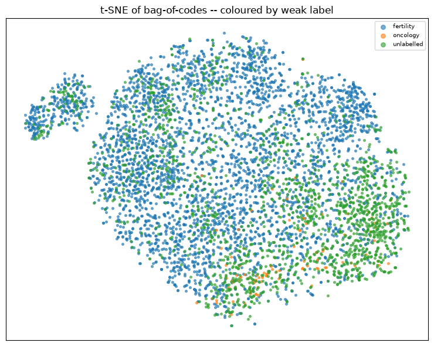

```python
from sklearn.manifold import TSNE

# Colour the plot by whatever ground truth we have: the planted archetype on
# demo data, or our weak fertility/oncology probe label on real data.
colour = (truth.set_index('person_id').archetype.reindex(X.index)
          if truth is not None
          else lab.reindex(X.index).fillna('unlabelled'))

# t-SNE takes the first ~24 SVD dimensions and squashes them down to 2, purely
# for visualization -- it is not itself a clustering method.
E = TSNE(n_components=2, init='pca', perplexity=30,
         random_state=0).fit_transform(Z[:, :min(24, Z.shape[1])])

fig, ax = plt.subplots(figsize=(7.5, 6))
for name, g in pd.DataFrame({'x': E[:,0], 'y': E[:,1],
                             'c': colour.values}).groupby('c', dropna=False):
    ax.scatter(g.x, g.y, s=7, alpha=.6, label=str(name))
ax.legend(fontsize=7, markerscale=2); ax.set_xticks([]); ax.set_yticks([])
ax.set_title('t-SNE of bag-of-codes' +
             (' -- coloured by planted truth (demo)' if truth is not None
              else ' -- coloured by weak label'))
plt.tight_layout(); plt.show()
```

### Three things never to claim from a t-SNE or UMAP plot

*These plots are seductive because they're pretty and look like "the answer." They aren't. Treat them as a rough sketch, not a measurement.*

1. Cluster **sizes** are meaningful. They are not.
2. **Distances between** clusters are meaningful. They are not.
3. Apparent **density** is meaningful. It is a function of perplexity.

Never cluster on the 2-D output. Cluster in SVD space; use the projection only to look.